# Metodology

In this notebook, we employ different machine learning models to predict whether a certain type of data belongs to a specific category. The primary focus is on classification, where the goal is to assign an input data point to one of several predefined classes. We use the following models:

### Random Forest

This model enhances the capabilities of a decision tree model by creating an ensemble of multiple decision trees and combining their predictions.

### K nearest neighbors

This model classifies data points based on the categories of their nearest neighbors in the feature space. It is a simple and intuitive algorithm that makes predictions by considering the 'k' closest data points to the input point.

### Gradient Boosting

Gradient Boosting is a powerful ensemble learning technique that builds a series of decision trees sequentially. Each new tree attempts to correct the errors made by the previous trees, improving the model's accuracy with each step.

### Decission Tree

A Decision Tree is a machine learning model that creates a tree-like structure to make decisions based on the input features. It recursively splits the data into subsets based on the most significant features, forming a tree with nodes representing the decisions or conditions.

### Linear Discriminant Analysis

Linear Discriminant Analysis (LDA) is a classification algorithm that finds a linear combination of features that best separates two or more classes of objects or events.

### Ensemble (personalized model)

# Experimental Section

### Database

I employ a database that was given to me in a csv format, the data is already cleaned. It contains 427 rows and 9 columns counting the target variable.

In order to improve the results in the models I applied a Standardization to the data, this ensure that all the data will be in the same scale. Also this improve the perfomance in models like KNN.

### Variables

As I mentioned, the database contains 8 classifiers. In the final results, we will assess the importance of each classifier in the model selection process. The classifiers are as follows:

*f(vij=1/q0)

*ΔD4(sIV)

*ΔD7(sIII)

*ΔD2(sII)

*ΔD1(sI)

*ΔD3(sIII)

*ΔD5(sI)

*ΔD6(sII)

# 1. Libraries

```python
# Básicas para manipulación
import numpy as np
import pandas as pd
import sklearn as sk

# Preprocesamiento
from sklearn.preprocessing import StandardScaler, MinMaxScaler, Normalizer, RobustScaler
from sklearn.decomposition import PCA

# Métricas
from sklearn.utils.class_weight import compute_class_weight
from sklearn.metrics import (confusion_matrix, ConfusionMatrixDisplay, classification_report, roc_auc_score, auc,
                             precision_recall_curve, roc_curve, f1_score, cohen_kappa_score)
from sklearn.pipeline import Pipeline

# Matplotlib
from matplotlib import pyplot
import matplotlib.pyplot as plt
from mpl_toolkits.mplot3d import Axes3D

# Modelos
from sklearn.linear_model import LogisticRegression
from sklearn.svm import LinearSVC
from sklearn.neighbors import KNeighborsClassifier
from sklearn.tree import DecisionTreeClassifier, plot_tree
from sklearn.ensemble import (RandomForestClassifier, GradientBoostingClassifier, VotingClassifier,
                              HistGradientBoostingClassifier)
from sklearn.discriminant_analysis import LinearDiscriminantAnalysis
from imblearn.ensemble import BalancedBaggingClassifier
import imblearn

# Transformación, ajustes y validaciones
from sklearn.model_selection import (train_test_split, KFold, StratifiedKFold, cross_validate,
                                     RandomizedSearchCV, GridSearchCV, RepeatedKFold)
from skopt import BayesSearchCV
from sklearn.feature_selection import RFE # Selector de Características Relevantes

# Análisis e interpretación
from sklearn.inspection import permutation_importance, PartialDependenceDisplay
import shap
from scipy.stats import pearsonr

# Remove convergence warnings
import warnings
from sklearn.exceptions import ConvergenceWarning, DataConversionWarning

# Visualización de árboles
from sklearn.tree import export_graphviz
import graphviz

# Exportaciones
import pickle
import multiprocessing

# Enable HistGradientBoosting
from sklearn.experimental import enable_hist_gradient_boosting

# Collections
from collections import Counter

# Suppress warnings
warnings.filterwarnings("ignore", category=UserWarning, module="sklearn")
warnings.filterwarnings("ignore", category=RuntimeWarning, module="numpy.ma.core")

# Install imbalance
```

# Adjust the data

```python
data=pd.read_csv("Data_Ceramidas.csv",sep=",")


Y_g=data.iloc[:,0]
X_g=data.iloc[:,1:]
#estandarizar los datps
X=pd.DataFrame(StandardScaler().fit_transform(X_g),columns=X_g.columns)
X.head()
```

|  | f(vij=1/q0)ref | ΔD1(sI) | ΔD2(sII) | ΔD3(sIII) | ΔD4(sIV) | ΔD5(sI) | ΔD6(sII) | ΔD7(sIII) |
| --- | --- | --- | --- | --- | --- | --- | --- | --- |
| 0 | -0.627671 | -0.084245 | 0.310846 | -0.638481 | 0.382702 | -0.627546 | -0.213335 | -0.024358 |
| 1 | -1.097719 | -0.084245 | 0.310846 | -0.638481 | 0.382702 | -0.627546 | -0.213335 | -0.024358 |
| 2 | 0.469108 | -0.084245 | 0.485334 | -0.638481 | 0.382702 | -0.627546 | -0.270792 | 0.088192 |
| 3 | -0.627671 | -0.084245 | 0.693153 | -0.638481 | 0.382702 | -0.627546 | -0.214549 | -0.024358 |
| 4 | -1.097719 | -0.084245 | -0.193388 | -0.638481 | 0.382702 | -0.627546 | 0.669931 | -0.024358 |

# Random Forest

```python
X_train_rf,X_test_rf,Y_train_rf,Y_test_rf=train_test_split(X,Y_g,test_size=0.33, random_state=42)

randomforest=RandomForestClassifier()

params={
    "criterion":["gini","entropy"],
    "max_depth":list(range(200,210)),
    "min_samples_split":list(range(5,15)),
    "min_samples_leaf":list(range(1,5))
}

grid_search=GridSearchCV(randomforest,params,scoring="accuracy",cv=RepeatedKFold(n_splits=3, n_repeats=1, random_state=123),n_jobs=-1)
grid_search.fit(X_train_rf,Y_train_rf)

randomforest_b=grid_search.best_estimator_
```

## Confusion Matrix

```
<sklearn.metrics._plot.confusion_matrix.ConfusionMatrixDisplay at 0x28f672f2630>
```

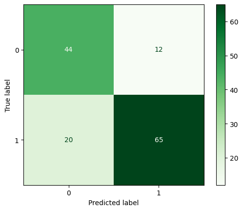

```python
Y_pred_rf=randomforest_b.predict(X_test_rf)
cm=confusion_matrix(Y_pred_rf,Y_test_rf)
ConfusionMatrixDisplay(confusion_matrix = cm).plot(cmap = plt.cm.Greens)
```

```python
importances = randomforest_b.feature_importances_
indices = np.argsort(importances)[::-1]
c_names=X_train_rf.columns
# Print the feature ranking
print("Feature ranking:")

for f in range(X_train_rf.shape[1]):
    print(f"{f + 1}. Feature {c_names[f]} ({importances[indices[f]]})")
```

```
Feature ranking:
1. Feature f(vij=1/q0)ref (0.3490474761781222)
2. Feature ΔD1(sI) (0.13105355783248468)
3. Feature ΔD2(sII) (0.12463559181406952)
4. Feature ΔD3(sIII) (0.11040104443617746)
5. Feature ΔD4(sIV) (0.0923287638494812)
6. Feature ΔD5(sI) (0.07651673180368103)
7. Feature ΔD6(sII) (0.061036517419697935)
8. Feature ΔD7(sIII) (0.05498031666628596)
```

```python
print(classification_report(Y_test_rf,Y_pred_rf))
```

```
              precision    recall  f1-score   support

           0       0.79      0.69      0.73        64
           1       0.76      0.84      0.80        77

    accuracy                           0.77       141
   macro avg       0.78      0.77      0.77       141
weighted avg       0.77      0.77      0.77       141
```

# KNN

```python
class_weights = {0: 0.57, 1: 0.43}

X_train_knn, X_test_knn, Y_train_knn, Y_test_knn = train_test_split(X, Y_g, test_size=0.33, random_state=42)

knnmodel = KNeighborsClassifier()

params = {
    'weights': ['uniform', 'distance'],
    'metric': ['minkowski', 'cosine', 'chebyshev'],
    'p': [1, 2, 3],
    'n_neighbors': list(range(5, 35)),  # Rango de valores para n_neighbors,
}

bestknn = GridSearchCV(knnmodel, params, cv=RepeatedKFold(n_splits=3, n_repeats=1, random_state=123), scoring="accuracy", n_jobs=-1)
bestknn.fit(X_train_knn, Y_train_knn)



knnmodel_b = bestknn.best_estimator_
```

## Confusion Matrix

```
[[42 22]
 [11 66]]
```

```
<sklearn.metrics._plot.confusion_matrix.ConfusionMatrixDisplay at 0x28f67698680>
```

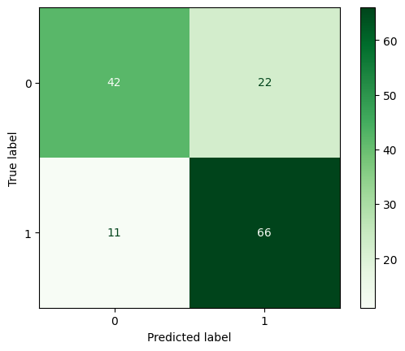

```python
Y_pred_knn=knnmodel_b.predict(X_test_knn)
cm_knn=confusion_matrix(Y_test_knn,Y_pred_knn)
print(cm_knn)
ConfusionMatrixDisplay(confusion_matrix = cm_knn).plot(cmap = plt.cm.Greens)
```

```python
print(classification_report(Y_test_knn,Y_pred_knn))
```

```
              precision    recall  f1-score   support

           0       0.79      0.66      0.72        64
           1       0.75      0.86      0.80        77

    accuracy                           0.77       141
   macro avg       0.77      0.76      0.76       141
weighted avg       0.77      0.77      0.76       141
```

## Visualization

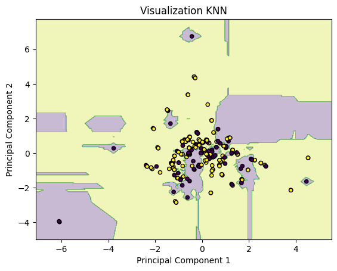

```python
pca=PCA(n_components=2)
X_train_pca = pca.fit_transform(X_train_knn)
X_test_pca = pca.transform(X_test_knn)
knn_pca = KNeighborsClassifier(**bestknn.best_params_)
knn_pca.fit(X_train_pca, Y_train_knn)
#crear la malla
x_min, x_max = X_train_pca[:, 0].min() - 1, X_train_pca[:, 0].max() + 1
y_min, y_max = X_train_pca[:, 1].min() - 1, X_train_pca[:, 1].max() + 1
xx, yy = np.meshgrid(np.arange(x_min, x_max, 0.02),
                     np.arange(y_min, y_max, 0.02))

# Predecir las clases para cada punto en la malla
Z = knn_pca.predict(np.c_[xx.ravel(), yy.ravel()])
Z = Z.reshape(xx.shape)

plt.contourf(xx, yy, Z, alpha=0.3)
plt.scatter(X_train_pca[:, 0], X_train_pca[:, 1], c=Y_train_knn, edgecolor='k', s=20)
plt.title("Visualization KNN")
plt.xlabel("Principal Component 1")
plt.ylabel("Principal Component 2")

plt.show()
```

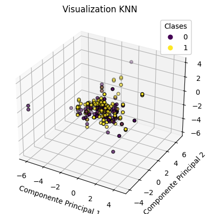

```python
# Apply PCA with 3 components
pca = PCA(n_components=3)
X_train_pca = pca.fit_transform(X_train_knn)
X_test_pca = pca.transform(X_test_knn)

# Train k-NN with the best parameters
knn_pca = KNeighborsClassifier(**bestknn.best_params_)
knn_pca.fit(X_train_pca, Y_train_knn)

# Visualize the data in 3D
fig = plt.figure()
ax = fig.add_subplot(111, projection='3d')

# Plot the training points
scatter = ax.scatter(X_train_pca[:, 0], X_train_pca[:, 1], X_train_pca[:, 2], c=Y_train_knn, edgecolor='k', s=20)

# Add the legend
legend1 = ax.legend(*scatter.legend_elements(), title="Clases")
ax.add_artist(legend1)

ax.set_title('Visualization KNN')
ax.set_xlabel('Componente Principal 1')
ax.set_ylabel('Componente Principal 2')
ax.set_zlabel('Componente Principal 3')

plt.show()
```

# Gradient Boosting

```python
X_train_gb, X_test_gb, Y_train_gb, Y_test_gb = train_test_split(X, Y_g, test_size=0.33, random_state=42)
param_grid = {
    'max_iter'      : [50, 100, 500, 1000],
    'max_depth'     : [3, 5, 10, 20],
    'learning_rate' : [0.001, 0.01, 0.1]
}


grid = GridSearchCV(
        estimator  = HistGradientBoostingClassifier(random_state=123),
        param_grid = param_grid,
        scoring    = 'accuracy',
        n_jobs     = multiprocessing.cpu_count() - 1,
        cv         = RepeatedKFold(n_splits=3, n_repeats=1, random_state=123),
        refit      = True,
        verbose    = 0,
        return_train_score = True
       )

grid.fit(X_train_gb, Y_train_gb)

gbmodel_b = grid.best_estimator_

#bestgb=GridSearchCV(gbmodel,grid,n_jobs=-1,cv=RepeatedKFold(n_splits=3, n_repeats=1, random_state=123),verbose=1,scoring="accuracy")
```

# Confusion Matrix

```
<sklearn.metrics._plot.confusion_matrix.ConfusionMatrixDisplay at 0x28f677e1520>
```

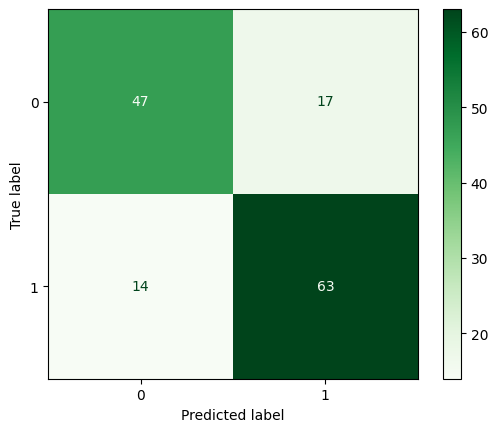

```python
Y_pred_gb=gbmodel_b.predict(X_test_gb)
cm_gb=confusion_matrix(Y_test_gb,Y_pred_gb)
ConfusionMatrixDisplay(confusion_matrix=cm_gb).plot(cmap=plt.cm.Greens)
```

```python
print(classification_report(Y_test_gb,Y_pred_gb))
```

```
              precision    recall  f1-score   support

           0       0.77      0.73      0.75        64
           1       0.79      0.82      0.80        77

    accuracy                           0.78       141
   macro avg       0.78      0.78      0.78       141
weighted avg       0.78      0.78      0.78       141
```

# Decission Tree

```python
X_train_dt,X_test_dt,Y_train_dt,Y_test_dt=train_test_split(X,Y_g,test_size=0.33,random_state=42)
dtmodel= DecisionTreeClassifier()
params = {
    'max_depth': [None, 10, 20, 30],
    'min_samples_split': [2, 10, 20],
    'min_samples_leaf': [1, 5, 10],
    'criterion': ['gini', 'entropy']
}

bestdt = GridSearchCV(dtmodel, params, cv=RepeatedKFold(n_splits=3, n_repeats=1, random_state=123), scoring="accuracy", n_jobs=-1)
bestdt.fit(X_train_dt,Y_train_dt)
dtmodel_b=bestdt.best_estimator_
```

### Purning

```
<sklearn.metrics._plot.confusion_matrix.ConfusionMatrixDisplay at 0x28f65209cd0>
```

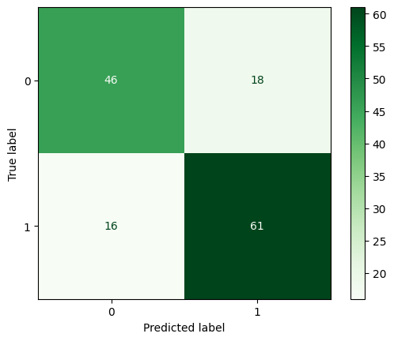

```python
X_train, X_val, Y_train, Y_val = train_test_split(X_train_dt, Y_train_dt, test_size=0.2, random_state=42)
class_weights = {0: 0.57, 1: 0.43}
path =dtmodel_b.cost_complexity_pruning_path(X_train_dt, Y_train_dt)
ccp_alphas, impurities = path.ccp_alphas, path.impurities
models=[]
for ca in ccp_alphas:
    dt_pruned=DecisionTreeClassifier(ccp_alpha=ca,**bestdt.best_params_,class_weight=class_weights, random_state=42)
    dt_pruned.fit(X_train_dt,Y_train_dt)
    models.append(dt_pruned)



best_pruned_dt = max(models, key=lambda model: model.score(X_val, Y_val))
predictions = best_pruned_dt.predict(X_test_dt)
cm_dt=confusion_matrix(Y_test_dt,predictions)
ConfusionMatrixDisplay(confusion_matrix=cm_dt).plot(cmap=plt.cm.Greens)
```

```python
print(classification_report(Y_test_dt,predictions))
```

```
              precision    recall  f1-score   support

           0       0.74      0.72      0.73        64
           1       0.77      0.79      0.78        77

    accuracy                           0.76       141
   macro avg       0.76      0.76      0.76       141
weighted avg       0.76      0.76      0.76       141
```

# Model_LDA

```python
X_train_LDA, X_test_LDA, y_train_LDA, y_test_LDA = train_test_split(X, Y_g, test_size=0.33, random_state=42)
priors = [0.5, 0.5]
LDA = LinearDiscriminantAnalysis(priors=priors)
LDA.fit(X_train_LDA, y_train_LDA)
```

```
LinearDiscriminantAnalysis(priors=[0.5, 0.5])
```

# Confusion Matrix

```
<sklearn.metrics._plot.confusion_matrix.ConfusionMatrixDisplay at 0x28f67897bc0>
```

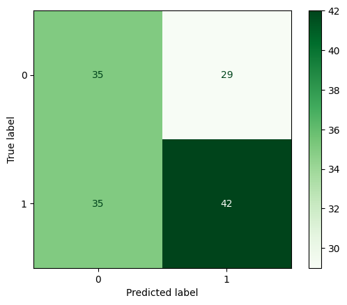

```python
Y_pred_lda=LDA.predict(X_test_LDA)
cm_lda=confusion_matrix(y_test_LDA,Y_pred_lda)
ConfusionMatrixDisplay(confusion_matrix=cm_lda).plot(cmap=plt.cm.Greens)
```

```python
print(classification_report(y_test_LDA,Y_pred_lda))
```

```
              precision    recall  f1-score   support

           0       0.50      0.55      0.52        64
           1       0.59      0.55      0.57        77

    accuracy                           0.55       141
   macro avg       0.55      0.55      0.54       141
weighted avg       0.55      0.55      0.55       141
```

# Esemble

```python
X_train_es,X_test_es,Y_train_es,Y_test_es=train_test_split(X,Y_g,test_size=0.33,random_state=42)

esemble=VotingClassifier(estimators=[
                                     ('rf',randomforest_b),
                                     ('knn',knnmodel_b),
                                     ('gb',gbmodel_b),
                                     ('DT',best_pruned_dt)
                                     ], voting='soft')

esemble.fit(X_train_es,Y_train_es)
```

```
VotingClassifier(estimators=[('rf',
                              RandomForestClassifier(max_depth=202,
                                                     min_samples_split=5)),
                             ('knn',
                              KNeighborsClassifier(n_neighbors=19, p=1,
                                                   weights='distance')),
                             ('gb',
                              HistGradientBoostingClassifier(max_depth=3,
                                                             max_iter=1000,
                                                             random_state=123)),
                             ('DT',
                              DecisionTreeClassifier(ccp_alpha=np.float64(0.0),
                                                     class_weight={0: 0.57,
                                                                   1: 0.43},
                                                     criterion='entropy',
                                                     max_depth=30,
                                                     min_samples_split=10,
                                                     random_state=42))],
                 voting='soft')
```

```
<sklearn.metrics._plot.confusion_matrix.ConfusionMatrixDisplay at 0x28f003086e0>
```

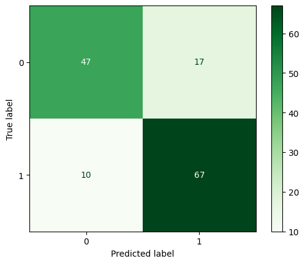

```python
Y_pred_es=esemble.predict(X_test_es)
cm_es=confusion_matrix(Y_test_es,Y_pred_es)
ConfusionMatrixDisplay(confusion_matrix=cm_es).plot(cmap=plt.cm.Greens)
```

```python
print(classification_report(Y_test_es,Y_pred_es))
```

```
              precision    recall  f1-score   support

           0       0.82      0.73      0.78        64
           1       0.80      0.87      0.83        77

    accuracy                           0.81       141
   macro avg       0.81      0.80      0.80       141
weighted avg       0.81      0.81      0.81       141
```

# ROC and AUC

In this section we will see how is the perfomance of a model in a visual way. The ROC curve represents the perfomance of a classification model at all classification thresholds.

AUC (Area under ROC curve) provides an aggregate measure of performance across all possible classification thresholds.

```python
prob_test_dt=best_pruned_dt.predict_proba(X_test_dt)[:,1]
fpr_test_dt,tpr_test_dt,thresholds_test_dt=roc_curve(Y_test_dt,prob_test_dt)
roc_auc_test_dt = auc(fpr_test_dt,tpr_test_dt)
```

```python
prob_test_rf = randomforest_b.predict_proba(X_test_rf)[:, 1]
fpr_test_rf, tpr_test_rf, thresholds_test_rf = roc_curve(Y_test_rf, prob_test_rf )
roc_auc_test_rf = auc(fpr_test_rf, tpr_test_rf)
```

```python
prob_test_knn = knnmodel_b.predict_proba(X_test_knn)[:, 1]
fpr_test_knn, tpr_test_knn, thresholds_test_rf = roc_curve(Y_test_knn, prob_test_knn )
roc_auc_test_knn = auc(fpr_test_knn, tpr_test_knn)
```

```python
prob_test_gb=gbmodel_b.predict_proba(X_test_gb)[:, 1]
fpr_test_gb,tpr_test_gb,threshold_test_gb=roc_curve(Y_test_gb,prob_test_gb)
roc_auc_test_gb=auc(fpr_test_gb,tpr_test_gb)
```

```python
prob_test_ens=esemble.predict_proba(X_test_es)[:,1]
fpr_test_ens,tpr_test_ens,thresholds_test_ens=roc_curve(Y_test_es,prob_test_ens)
roc_auc_test_ens = auc(fpr_test_ens,tpr_test_ens)
```

```python
prob_test_lda=LDA.predict_proba(X_test_LDA)[:,1]
fpr_test_lda,tpr_test_lda,thresholds_test_lda=roc_curve(Y_test_es,prob_test_lda)
roc_auc_test_lda = auc(fpr_test_lda,tpr_test_lda)
```

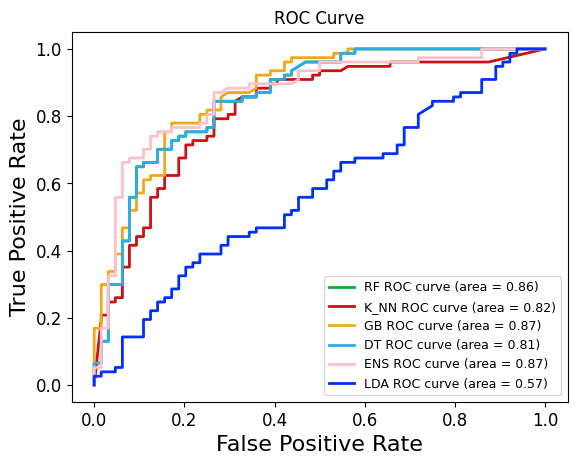

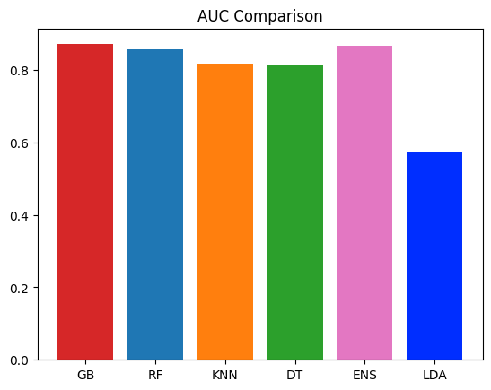

```python
plt.plot(fpr_test_rf, tpr_test_rf, color='#0BAD32', lw=2, label='RF ROC curve (area = %0.2f)' % roc_auc_test_rf) #random forest
plt.plot(fpr_test_knn, tpr_test_knn, color='#CC1013', lw=2, label='K_NN ROC curve (area = %0.2f)' % roc_auc_test_knn) #knn
plt.plot(fpr_test_gb,tpr_test_gb, color='#F0A818', lw=2, label='GB ROC curve (area = %0.2f)' % roc_auc_test_gb) #gb

plt.plot(fpr_test_rf, tpr_test_rf, color='#2DACEB', lw=2, label='DT ROC curve (area = %0.2f)' % roc_auc_test_dt) #dt

plt.plot(fpr_test_ens, tpr_test_ens, color='#FFC0CB', lw=2, label='ENS ROC curve (area = %0.2f)' % roc_auc_test_ens) #ens

plt.plot(fpr_test_lda, tpr_test_lda, color='#002EFF', lw=2, label='LDA ROC curve (area = %0.2f)' % roc_auc_test_lda) #LDA

plt.xlabel('False Positive Rate', fontsize=16)
plt.ylabel('True Positive Rate', fontsize=16)

plt.xticks(fontsize=12)
plt.yticks(fontsize=12)

# Set the limits of the x-axis and y-axis with a space before and after
plt.xlim([0 - 0.05, 1.05])  # Limit the x-axis up to 1.05
plt.gca().set_ylim([0 - 0.05, 1 + 0.05])

plt.legend(loc="lower right", fontsize=9)
plt.title("ROC Curve")
# Save image with transparent background and resolution of 600 dpi
plt.show()

#AUC Curve Comparassion
fig,ax=plt.subplots()
models_names=["GB","RF","KNN","DT","ENS","LDA"]
auc_values=[roc_auc_test_gb,roc_auc_test_rf,roc_auc_test_knn,roc_auc_test_dt,roc_auc_test_ens,roc_auc_test_lda]
bar_colors=['tab:red', 'tab:blue', 'tab:orange','tab:green','tab:pink','#002EFF']
ax.bar(models_names,auc_values,color=bar_colors)
plt.title("AUC Comparison")
plt.show()
```

# Cohen Kappa

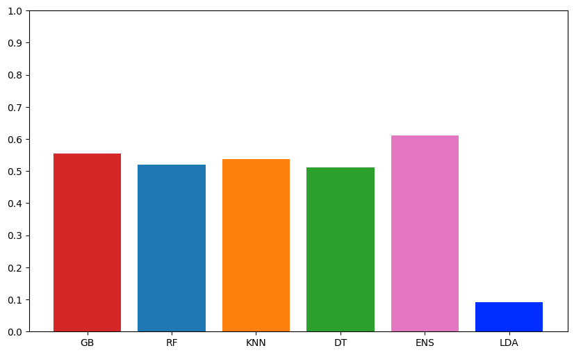

```python
kappa_gb=cohen_kappa_score(Y_test_gb,Y_pred_gb)
kappa_gb
kappa_knn=cohen_kappa_score(Y_test_knn,Y_pred_knn)
kappa_rf=cohen_kappa_score(Y_test_rf,Y_pred_rf)
kappa_dt=cohen_kappa_score(Y_test_dt,predictions)
kappa_ens=cohen_kappa_score(Y_test_es,Y_pred_es)
kappa_lda=cohen_kappa_score(y_test_LDA,Y_pred_lda)
models_names=["GB","RF","KNN","DT","ENS","LDA"]
kappa_values=[kappa_gb,kappa_knn,kappa_rf,kappa_dt,kappa_ens,kappa_lda]

plt.figure(figsize=(10, 6))
plt.bar(models_names,kappa_values,color=['tab:red', 'tab:blue', 'tab:orange','tab:green','tab:pink',"#002EFF"])
plt.ylim(0,1)
plt.yticks(np.arange(0, 1.1, 0.1))
plt.show()
```

# Importances of features

## KNN

```python
# Calculate permutation importances
impknn = permutation_importance(knnmodel_b, X_test_knn, Y_test_knn, n_repeats=10, random_state=42, n_jobs=-1)
importances_mean_knn = impknn.importances_mean
importances_std_knn = impknn.importances_std
categories = X_train_knn.columns

feature_importances = [
    (categories[i], importances_mean_knn[i], importances_std_knn[i])
    for i in range(len(importances_mean_knn))
]

sorted_feature_importances = sorted(feature_importances, key=lambda x: x[1], reverse=True)

# Print sorted features with their importances
for feature_name, mean_importance, std_importance in sorted_feature_importances:
    print(f"Feature {feature_name} mean: {mean_importance:.4f} sd: {std_importance:.4f}")
```

```
Feature f(vij=1/q0)ref mean: 0.2546 sd: 0.0461
Feature ΔD4(sIV) mean: 0.0248 sd: 0.0120
Feature ΔD7(sIII) mean: 0.0199 sd: 0.0069
Feature ΔD2(sII) mean: 0.0184 sd: 0.0156
Feature ΔD1(sI) mean: 0.0142 sd: 0.0222
Feature ΔD3(sIII) mean: 0.0064 sd: 0.0074
Feature ΔD5(sI) mean: -0.0007 sd: 0.0121
Feature ΔD6(sII) mean: -0.0092 sd: 0.0135
```

## Random Forest

```python
importancesrf=randomforest_b.feature_importances_

categories = X_train_knn.columns
imprf = permutation_importance(randomforest_b, X_test_rf, Y_test_rf, n_repeats=10, random_state=42, n_jobs=-1)
meanrf=imprf.importances_mean
stdrf=imprf.importances_std
joined=[
    (categories[i],meanrf[i],stdrf[i])
    for i in range(len(meanrf))
]
importances_rf = randomforest_b.feature_importances_


joined_sorted=sorted(joined,key=lambda x : x[1], reverse=True)


for n,m,std in joined_sorted:
    print(f"{n} mean: {m} std: {std}")
```

```
f(vij=1/q0)ref mean: 0.2163120567375887 std: 0.04316929870505874
ΔD1(sI) mean: 0.016312056737588666 std: 0.01455197484303772
ΔD2(sII) mean: 0.010638297872340418 std: 0.024822695035460987
ΔD6(sII) mean: 0.0028368794326241176 std: 0.010129685714245192
ΔD5(sI) mean: -0.004964539007092206 std: 0.017956012625776143
ΔD4(sIV) mean: -0.012765957446808519 std: 0.014465303584660387
ΔD7(sIII) mean: -0.013475177304964558 std: 0.009750161053097546
ΔD3(sIII) mean: -0.02056737588652483 std: 0.01025307254950421
```

## Gradient Boosting

```python
categories = X_train_gb.columns
impgb = permutation_importance(gbmodel_b, X_test_gb, Y_test_gb, n_repeats=10, random_state=42, n_jobs=-1)
meangb=impgb.importances_mean
stdgb=impgb.importances_std
joined_gb=[
    (categories[i],meangb[i],stdgb[i])
    for i in range(len(meangb))
]
joined_sorted_gb=sorted(joined_gb,key=lambda x : x[1], reverse=True)


for n,m,std in joined_sorted_gb:
    print(f"{n} mean: {m} std: {std}")
```

```
f(vij=1/q0)ref mean: 0.24255319148936172 std: 0.038819665768522
ΔD2(sII) mean: 0.01205673758865249 std: 0.020567375886524835
ΔD6(sII) mean: 0.0070921985815603165 std: 0.024155157965853054
ΔD3(sIII) mean: 0.0 std: 0.005493593398875777
ΔD1(sI) mean: -0.0007092198581560294 std: 0.014343083983089868
ΔD4(sIV) mean: -0.0007092198581560294 std: 0.013623668590282677
ΔD5(sI) mean: -0.013475177304964536 std: 0.009750161053097513
ΔD7(sIII) mean: -0.01914893617021276 std: 0.01101005297607092
```

## DT

```python
categories = X_train_dt.columns
impdt = permutation_importance(best_pruned_dt, X_test_dt, Y_test_dt, n_repeats=10, random_state=42, n_jobs=-1)
meandt=impdt.importances_mean
stddt=impdt.importances_std
joined_dt=[
    (categories[i],meandt[i],stddt[i])
    for i in range(len(meandt))
]
importances_dt=best_pruned_dt.feature_importances_
joined_sorted_dt=sorted(joined_dt,key=lambda x : x[1], reverse=True)


for n,m,std in joined_sorted_dt:
    print(f"{n} mean: {m} std: {std}")
```

```
f(vij=1/q0)ref mean: 0.24042553191489358 std: 0.03967196105233191
ΔD2(sII) mean: 0.031205673758865238 std: 0.018548506142726247
ΔD5(sI) mean: 0.030496453900709198 std: 0.017673667793442687
ΔD6(sII) mean: 0.02695035460992906 std: 0.013000214737463352
ΔD4(sIV) mean: 0.013475177304964536 std: 0.010732443936469166
ΔD1(sI) mean: 0.009929078014184401 std: 0.010129685714245162
ΔD7(sIII) mean: 0.006382978723404253 std: 0.01398800207327377
ΔD3(sIII) mean: -0.007801418439716323 std: 0.002127659574468088
```

## LDA

```python
categories = X_train_LDA.columns
implda = permutation_importance(LDA, X_test_LDA, y_test_LDA, n_repeats=10, random_state=42, n_jobs=-1)
meanlda=implda.importances_mean
stdlda=implda.importances_std
joined_lda=[
    (categories[i],meanlda[i],stdlda[i])
    for i in range(len(meanlda))
]

joined_sorted_lda=sorted(joined_lda,key=lambda x : x[1], reverse=True)


for n,m,std in joined_sorted_lda:
    print(f"{n} mean: {m} std: {std}")
```

```
ΔD1(sI) mean: 0.02836879432624116 std: 0.022871653186662556
f(vij=1/q0)ref mean: 0.024113475177304992 std: 0.04113475177304966
ΔD6(sII) mean: 0.016312056737588676 std: 0.012304504661629433
ΔD7(sIII) mean: 0.01134751773049647 std: 0.007897538103305006
ΔD3(sIII) mean: 0.007801418439716323 std: 0.00865713164236434
ΔD5(sI) mean: 0.007801418439716323 std: 0.00865713164236434
ΔD4(sIV) mean: 0.002127659574468088 std: 0.013096585328098875
ΔD2(sII) mean: -0.02765957446808509 std: 0.03538289271848631
```

## Essemble

```python
categories = X_train_es.columns
impes = permutation_importance(esemble, X_test_es, Y_test_es, n_repeats=10, random_state=42, n_jobs=-1)
meanes=impes.importances_mean
stdes=impes.importances_std
joined_es=[
    (categories[i],meanes[i],stdes[i])
    for i in range(len(meanes))
]


joined_sorted_es=sorted(joined_es,key=lambda x : x[1], reverse=True)


for n,m,std in joined_sorted_es:
    print(f"{n} mean: {m} std: {std}")
```

```
f(vij=1/q0)ref mean: 0.26808510638297867 std: 0.03682483683899907
ΔD1(sI) mean: 0.029787234042553123 std: 0.011782445195628492
ΔD2(sII) mean: 0.029078014184397104 std: 0.021616667594508056
ΔD6(sII) mean: 0.025531914893616958 std: 0.020358439850223165
ΔD7(sIII) mean: 0.014893617021276529 std: 0.012864083083132655
ΔD4(sIV) mean: 0.012056737588652389 std: 0.0063829787234042645
ΔD5(sI) mean: 0.009929078014184346 std: 0.014255142724994148
ΔD3(sIII) mean: -2.2204460492503132e-17 std: 0.0077691142908533906
```

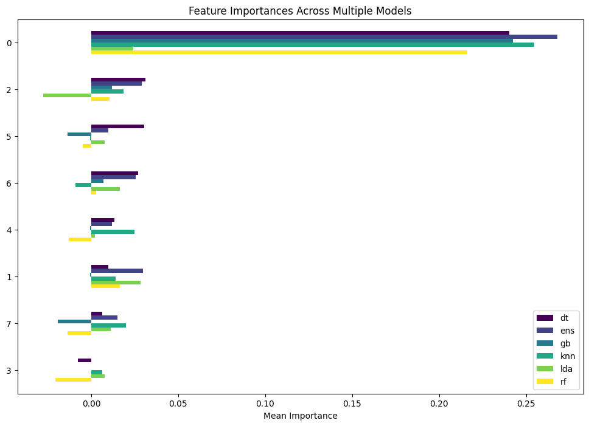

```python
importances_g={
    'dt':meandt,
    'ens':meanes,
    'gb':meangb,
    'knn':importances_mean_knn,
    'lda':meanlda,
    'rf':meanrf
}
importances_info={
    'dt':importances_dt,
    'rf':importances_rf
}

#export



categories = X_train_es.columns

imp_gi=pd.DataFrame(importances_info)
imp_gi.insert(0,'features',categories)
imp_gi.to_csv('importances_info.csv')

imp_df=pd.DataFrame(importances_g)
imp_df.insert(0,'Carac',categories)
imp_df.to_csv('importances.csv')
imp_df = imp_df.sort_values(by='dt', ascending=False)



fig, ax = plt.subplots(figsize=(12, 8))
imp_df.plot(kind='barh', ax=ax, colormap='viridis')
plt.xlabel('Mean Importance')
plt.title('Feature Importances Across Multiple Models')
plt.gca().invert_yaxis()

plt.show()
```

# Metric Exportation

```python
models={
    'DT':best_pruned_dt,
    'KNN':knnmodel_b,
    'ENS':esemble,
    'LDA':LDA,
    'RF':randomforest_b,
    'GB':gbmodel_b
}

metrics=['f1','accuracy','recall','precision']
results={}
for name in models:
    cvresult=cross_validate(models[name], X_test_dt,Y_test_dt, cv=StratifiedKFold(n_splits=7, random_state=42, shuffle=True),scoring=metrics)
    scores={}
    for metric in metrics:
        scores[metric]=cvresult[f"test_{metric}"]
        print(scores)

    results[name]=scores
```

[output not shown]

[output cut: 29 more lines]

```
       0.9       , 0.69230769])}
{'f1': array([0.66666667, 0.81818182, 0.72727273, 0.63636364, 0.7826087 ,
       0.85714286, 0.66666667])}
{'f1': array([0.66666667, 0.81818182, 0.72727273, 0.63636364, 0.7826087 ,
       0.85714286, 0.66666667]), 'accuracy': array([0.66666667, 0.8       , 0.7       , 0.6       , 0.75      ,
       0.85      , 0.65      ])}
{'f1': array([0.66666667, 0.81818182, 0.72727273, 0.63636364, 0.7826087 ,
       0.85714286, 0.66666667]), 'accuracy': array([0.66666667, 0.8       , 0.7       , 0.6       , 0.75      ,
       0.85      , 0.65      ]), 'recall': array([0.63636364, 0.81818182, 0.72727273, 0.63636364, 0.81818182,
       0.81818182, 0.63636364])}
{'f1': array([0.66666667, 0.81818182, 0.72727273, 0.63636364, 0.7826087 ,
       0.85714286, 0.66666667]), 'accuracy': array([0.66666667, 0.8       , 0.7       , 0.6       , 0.75      ,
       0.85      , 0.65      ]), 'recall': array([0.63636364, 0.81818182, 0.72727273, 0.63636364, 0.81818182,
       0.81818182, 0.63636364]), 'precision': array([0.7       , 0.81818182, 0.72727273, 0.63636364, 0.75      ,
       0.9       , 0.7       ])}
```

```python
for metric in metrics:
    RES = pd.DataFrame({model:results[model][metric] for model in models})
    print(metric)
    print(RES)
    RES.to_excel(f"Resultados_{metric}.xlsx")
```

```
f1
         DT       KNN       ENS       LDA        RF        GB
0  0.750000  0.695652  0.782609  0.600000  0.727273  0.666667
1  0.782609  0.833333  0.782609  0.583333  0.833333  0.818182
2  0.761905  0.761905  0.818182  0.700000  0.761905  0.727273
3  0.583333  0.545455  0.666667  0.476190  0.571429  0.636364
4  0.736842  0.818182  0.818182  0.692308  0.857143  0.782609
5  0.736842  0.857143  0.857143  0.700000  0.857143  0.857143
6  0.818182  0.421053  0.782609  0.315789  0.750000  0.666667
accuracy
         DT       KNN       ENS       LDA        RF        GB
0  0.714286  0.666667  0.761905  0.619048  0.714286  0.666667
1  0.750000  0.800000  0.750000  0.500000  0.800000  0.800000
2  0.750000  0.750000  0.800000  0.700000  0.750000  0.700000
3  0.500000  0.500000  0.600000  0.450000  0.550000  0.600000
```

[output cut: 21 more lines]

## Box plot of metrics with no ranked data

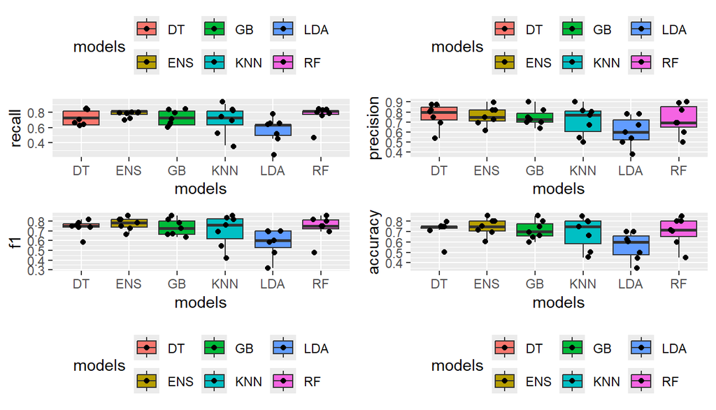

## Box plot with ranked data

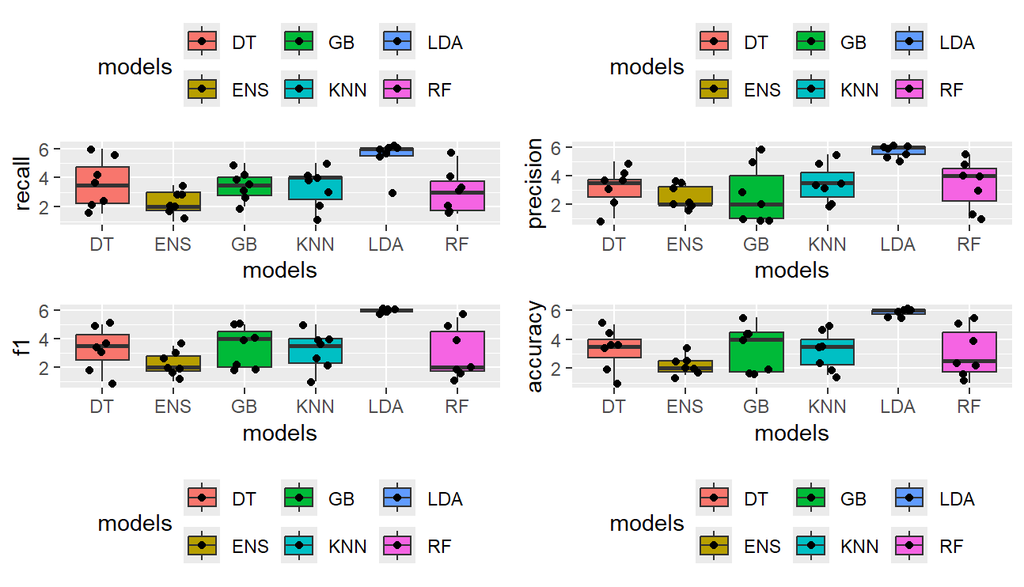

As we can see of this two graphs is that with ranked data we can see which model is having the best perfomance. The ensemble model is the most close to the first rank in all the metrics, also it dosent have too much dispersion in the results

### Interpretation

Interpretation of the Boxplot

Median:

The line inside the box indicates the median. If it is closer to Q1 or Q3, it indicates skewness in the distribution. Dispersion:

The size of the box (Q3 - Q1) indicates the variability or dispersion of the data in the central 50%. A large IQR suggests greater dispersion. Symmetry and Skewness:

If the median is centered within the box and the whiskers are approximately the same length, the distribution is approximately symmetrical. If the median is not centered and one whisker is longer than the other, the distribution is skewed. For example, if the upper whisker is longer, there is a long tail in the positive direction (positive skewness). Outliers:

Points outside the whiskers indicate outliers. The presence of many outliers can indicate a distribution with long tails or data that do not follow a typical distribution.

## Linear Discriminant

### Why LDA?

Linear Discriminant Analysis is useful for:

Classification: Determining which group a new observation belongs to based on the dependent variables.

Dimensionality Reduction: Identifying the linear combinations of variables that best discriminate between groups.

Visualization: Helping to visualize the separation between groups in a lower-dimensional space (for example, through plots of the discriminant functions).

### Graph with no ranked data

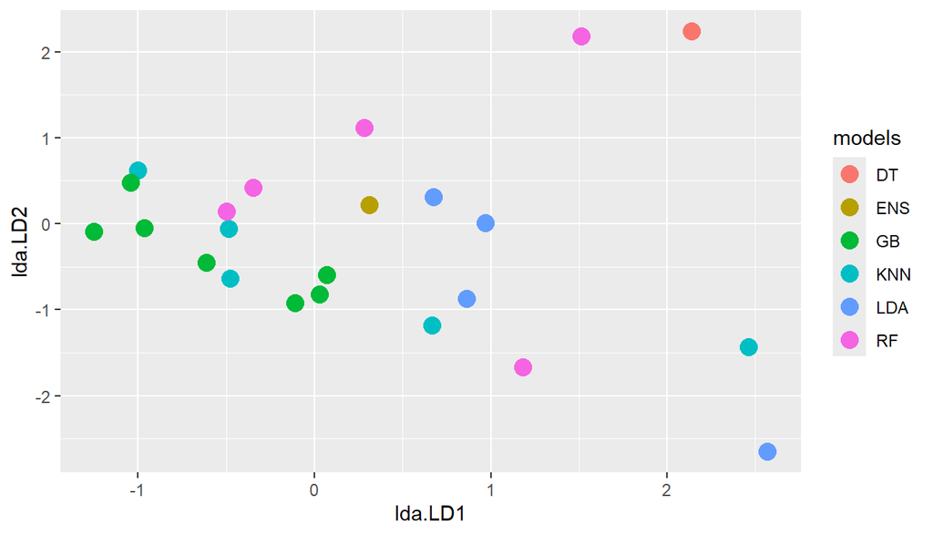

### Graph with ranked data

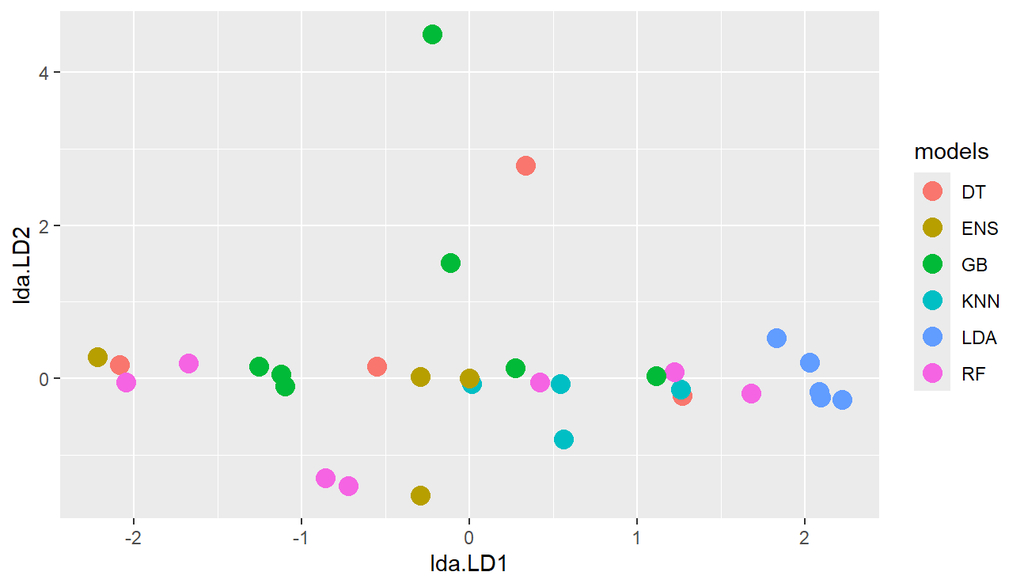

# Comparassion of the Classifiers

### Strengths and Weaknesses of Importance Gained by Information

```python
info_data=pd.read_csv("icbgi.csv")
print(info_data)
```

```
       Unnamed: 0  Strenghts   Weakness
0  f(vij=1/q0)ref           7         0
1         ΔD1(sI)           2         2
2        ΔD2(sII)           4         1
3       ΔD3(sIII)           0         7
4        ΔD4(sIV)           2         3
5         ΔD5(sI)           2         2
6        ΔD6(sII)           4         1
7       ΔD7(sIII)           1         6
```

### Strengths and Weaknesses of Permutation Importance

```python
info_data=pd.read_csv("icbp.csv")
print(info_data)
```

```
      Classifiers  Strenghts   Weakness
0  f(vij=1/q0)ref           6         0
1         ΔD1(sI)           0         0
2        ΔD2(sII)           0         1
3       ΔD3(sIII)           0         1
4        ΔD4(sIV)           0         1
5         ΔD5(sI)           0         1
6        ΔD6(sII)           0         1
7       ΔD7(sIII)           0         1
```

### Analysis of Dominance

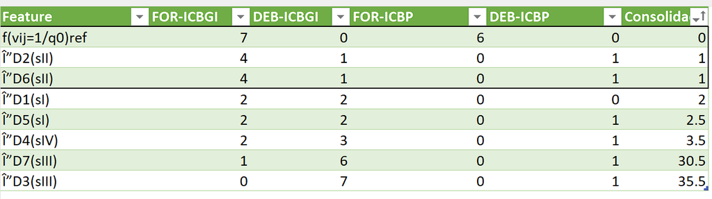

As we can see the classfier f(vij=1/q0)ref is the one that have more importance in the decission in the models. Also the variables Î”D2(sII) and Î”D6(sII) have an impact in the decissions.

# Conclusion

In this work, we evaluated different models to determine which ones provide the best performance with our data. We also identified the most important classifiers influencing the model's decisions. Our analysis involved examining various metrics such as accuracy, precision, recall, and F1-score to comprehensively assess each model's performance.

Based on these results, we can take several actions to improve our models. For instance, we can modify existing classifiers or introduce new ones to enhance the predictive power of our models. As shown in the final tables, some classifiers do not significantly impact the model's decisions, indicating potential areas for optimization or removal.

Additionally, the results indicate that the models with the best performance were those based on ensemble methods, such as Random Forest and Gradient Boosting. These methods combine multiple learning algorithms to achieve better predictive performance than individual models. Their success in our evaluations suggests that leveraging the strengths of various algorithms can lead to more robust and accurate predictions.

In conclusion, our findings highlight the importance of model evaluation and feature importance analysis in machine learning. By refining our classifiers and utilizing ensemble methods, we can continue to improve the accuracy and reliability of our predictive models.